# Modelling Multiple Seasons, Establishment Dates or Locations

Adam H. Sparks

2021-07-18

You may wish to compare the effects of different establishment dates, different seasons or different locations on disease levels. This vignette details how you can automate several runs of *epicrop* in R and visualise them. Examples are given that show how to run the process sequentially and in parallel, decreasing the runtime necessary and how to benchmark your processes to help optimise your workflow.

## Multiple seasons

### Fetching NASA POWER data for multiple seasons

Start by creating a list of the dates representing the seasons that you want to simulate. In this case, since we specify the duration of the season, there is no need to explicitly state the end-date, that will automatically be determined by `get_wth()` with the `duration` argument that we pass along in the `purrr::map()`. You can use as many start dates, representing as many seasons as you desire, but for the purposes of speed in this vignette, only two will be used.

```r
years <- 2000:2001
seasons <- paste0(years, "-06-30")
```

Next use `get_wth()` to fetch the weather data from the [POWER API](https://power.larc.nasa.gov). In this example we will use the IRRI Zeigler Experiment Station coordinates as shown in the example for `get_wth()`. With the vector of establishment dates, `seasons`, use `purrr::map()` to fetch all of the seasons with one function. You could also use R’s base `lapply()` here as well if you prefer.

```r
library("epicrop")
library("purrr")

seasons_wth <-
  map(
    .x = seasons,
    .f = get_wth,
    lonlat = c(121.255669, 14.16742),
    duration = 120
  )
```

### Using *purrr* to simplify the simulation of multiple seasons

Now that we have a list of weather data for two seasons we will use `purrr::map_df()` now to run `predict_bacterial_blight()` for two seasons and create a single data frame of the two seasons. Using `purrr::map()` as above would return a list of two data frames, if you wish. This behaviour would be the same as if you used R’s base `lapply()` here as well.

Add a column to specify the season, in this case we only have wet seasons for two years, but if you have multiple seasons per year, you can still use this template, *e.g.*, for multiple seasons in one year, use `lubridate::ymd()`.

```r
library("dplyr")
library("lubridate")
```

```r
library("epifitter")
library("pander")

seasons <- map_df(
  .x = seasons_wth,
  .f = ~ predict_bacterial_blight(emergence = .x$YYYYMMDD[1],
                                  wth = .x)
) %>%
  mutate(season = case_when(year(dates) == 2000 ~ 2000,
                            year(dates) == 2001 ~ 2001)) %>%
  group_by(season) %>%
  summarise(AUDPC(
    time = simday,
    y = intensity,
    y_proportion = FALSE,
    type = "absolute"
  )) %>%
  rename(AUDPC = 2)

pander(seasons)
```

| season | AUDPC |
| --- | --- |
| 2000 | 12.83 |
| 2001 | 7.476 |

### Visualising differences in AUDPC between seasons

A simple bar chart created using *ggplot2* is an effective way to visualise the difference between the two seasons.

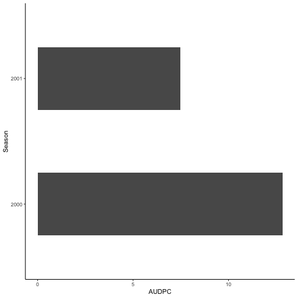

```r
library("ggplot2")
ggplot(seasons,
       aes(y = as.factor(season),
           x = AUDPC, )) +
  geom_col(width = 0.5,
           orientation = "y") +
  ylab("Season") +
  theme_classic()
```

### Simulating multiple seasons with *furrr* using parallel processing

Using *furrr*, we can do the same thing in parallel to reduce the runtime, especially if you have several seasons.

**Note on the use of parallel processing** > Use parallel processing with caution. *epicrop* is highly optimised for speed (as much as pure R can be). For small runs, *e.g.* one or two seasons or locations, this is will not reduce the time and may increase the run time due to overhead setting up and running the parallel processing. Best guess is that unless you have > 40 or 50 seasons or locations or some combinations thereof to run the processes in parallel will not be any benefit.

In this case, while this code runs, you can benchmark it and see that this is no faster and in some cases, slower than running the code sequentially. An example of benchmarking code is provided below.

```r
library("epicrop")
library("furrr")
library("dplyr")
library("lubridate")
library("epifitter")
library("pander")

# use 2 cores, this will assign one to each year, if you have more years and
# more cores, e.g., an HPC, explore using more resources
plan(multisession, workers = 2)

years <- 2000:2001
seasons <- paste0(years, "-06-30")
seasons_wth <-
  future_map(
    .x = seasons,
    .f = get_wth,
    lonlat = c(121.255669, 14.16742),
    duration = 120,
    .options = furrr_options(seed = NULL)
  )

# run predict_bacterial_blight() over the data frames of weather
future_map_dfr(
  .x = seasons_wth,
  .f = ~ predict_bacterial_blight(emergence = .x$YYYYMMDD[1],
                                  wth = .x),
  .options = furrr_options(seed = NULL)
) %>%
  mutate(season = case_when(year(dates) == 2000 ~ 2000,
                            year(dates) == 2001 ~ 2001)) %>%
  group_by(season) %>%
  summarise(AUDPC(
    time = simday,
    y = intensity,
    y_proportion = FALSE,
    type = "absolute"
  )) %>%
  rename(AUDPC = 2) %>%
  pander()
```

| season | AUDPC |
| --- | --- |
| 2000 | 12.83 |
| 2001 | 7.476 |

We can see here that the AUDPC values match using both processing methods.

## Multiple establishment dates

### Using *purrr* to simulate multiple establishment dates

To simulate multiple establishment dates and across multiple years at the same time we can use `purrr::cross2()` to create a vector of all year and month-day combinations that we wish to simulate.

Using `purrr::map2` allows for using two variables, one for weather data, `wth`, and one for the emergence/establishment dates, `emergence_dates`. This returns a list of data, but using `dplyr::bind_rows(.id = "emergence")` creates a data frame with a column of emergence/establishment dates that can be used for grouping the data for further analysis or visualisation.

```r
library("epicrop")
library("purrr")
library("dplyr")
library("lubridate")
library("epifitter")
library("pander")

years <- 2001:2010
month_day <- c("-06-01", "-06-14", "-06-30")
emergence_dates <-
  cross2(years, month_day) %>%
  map_chr(paste0, collapse = "") %>%
  sort() %>%
  as_date()

# create a vector of dates for weather data.
# Only take the earliest establishment date, then extend the duration out past
# 120 days from final establishment date.
# Here just taking 180 days, 6 months, works well.
wth_start_dates <- paste0(years, month_day[1])

seasons_wth <- map_dfr(
  .x = wth_start_dates,
  .f = get_wth,
  lonlat = c(121.255669, 14.16742),
  duration = 180
) %>%
  mutate(YYYYMMDD = as_date(YYYYMMDD))

# Once we have all the weather, create a list of weather data.frames for each
# establishment date
# Create time intervals to subset the weather data, creating a list new
# data.frames for each establishment date.

wth <-
  map(.x = emergence_dates,
      .f = ~ subset(seasons_wth, YYYYMMDD >= .x &
                      YYYYMMDD <= .x + 120)) %>%
  setNames(emergence_dates)

multi_dates <- map2(
  .x = wth,
  .y = emergence_dates,
  .f = ~ predict_bacterial_blight(emergence = .y,
                                  wth = .x)
) %>%
  bind_rows(.id = "emergence") %>%
  group_by(emergence) %>%
  summarise(AUDPC(
    time = simday,
    y = intensity,
    y_proportion = FALSE,
    type = "absolute"
  )) %>%
  rename(AUDPC = 2)
pander(multi_dates)
```

| emergence | AUDPC |
| --- | --- |
| 2001-06-01 | 15.28 |
| 2001-06-14 | 9.696 |
| 2001-06-30 | 7.476 |
| 2002-06-01 | 15.88 |
| 2002-06-14 | 14.36 |
| 2002-06-30 | 14.68 |
| 2003-06-01 | 12.64 |
| 2003-06-14 | 12.58 |
| 2003-06-30 | 17.21 |
| 2004-06-01 | 12.16 |
| 2004-06-14 | 15 |
| 2004-06-30 | 11.69 |
| 2005-06-01 | 16.35 |
| 2005-06-14 | 15.37 |
| 2005-06-30 | 16.21 |
| 2006-06-01 | 16.59 |
| 2006-06-14 | 16.18 |
| 2006-06-30 | 15.11 |
| 2007-06-01 | 10.26 |
| 2007-06-14 | 8.941 |
| 2007-06-30 | 14.23 |
| 2008-06-01 | 11.18 |
| 2008-06-14 | 11.02 |
| 2008-06-30 | 12.95 |
| 2009-06-01 | 9.119 |
| 2009-06-14 | 14.74 |
| 2009-06-30 | 12.37 |
| 2010-06-01 | 16.62 |
| 2010-06-14 | 18.07 |
| 2010-06-30 | 18.04 |

That’s a bit long and there’s lots of values to digest here.

### Visualising multiple establishment dates using a stem plot

A bar chart as with the previous example works, but it can be simplified and made more clear using a stem plot created with *ggplot2*. Using `ggplot2::geom_segment()` and `ggplot2::geom_point()` we can maximise the ink to information ratio and create an easy to view and interpret graph of these data.

Note the additional `ggplot2::aes()` parameters here, `xend` and `yend` are necessary since we’re using `ggplot2::geom_segment()`.

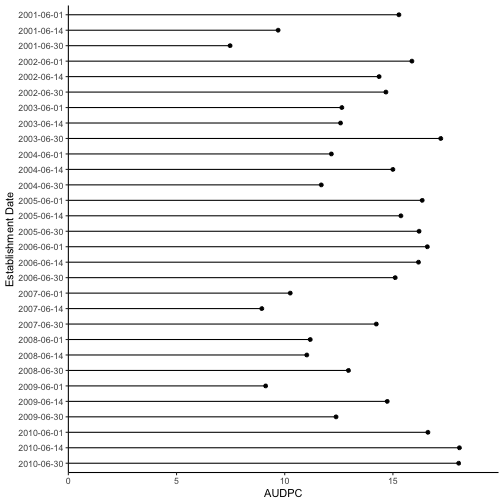

```r
library("ggplot2")
ggplot(data = multi_dates,
       aes(
         x = AUDPC,
         xend = 0,
         y = as.factor(emergence),
         yend = as.factor(emergence)
       )) +
  geom_segment() +
  geom_point() +
  scale_x_continuous(
    expand = expansion(mult = c(0, 0.1))  # remove space on left side of "0"
    ) +
  scale_y_discrete(limits = rev) + # alphabetical order top to bottom
                       ylab("Establishment Date") +
                       theme_classic()
```

### Using *furrr* to run multiple establishment dates in parallel

To run the previous example in parallel, substitute *furrr* equivalent functions for the *purrr* functions used above. These are easily identified by the `future_` prefix on each of the functions where they are used.

In this example rather than printing the whole table, the data are piped directly into the `ggplot2::ggplot()` function for creating a figure that again, is the same as the previous example, but run in parallel using *furrr*.

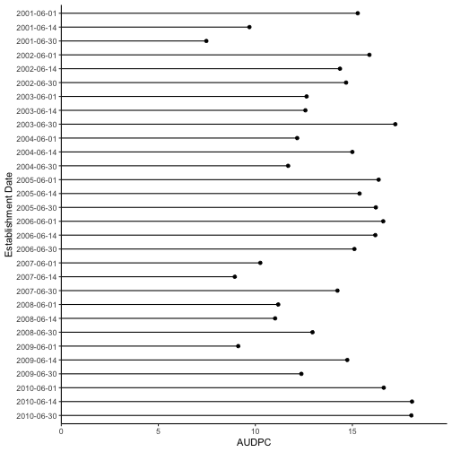

```r
library("furrr")
library("purrr")
library("dplyr")
library("ggplot2")
library("lubridate")
library("epicrop")
library("epifitter")

plan(multisession, workers = 2)

years <- 2001:2010
month_day <- c("-06-01", "-06-14", "-06-30")
emergence_dates <-
  cross2(years, month_day) %>%
  map_chr(paste0, collapse = "") %>%
  sort() %>%
  as_date()

# create a vector of dates for weather data.
# Only take the earliest establishment date, then extend the duration out past
# 120 days from final establishment date.
# Here just taking 180 days, 6 months, works well.
wth_start_dates <- paste0(years, month_day[1])

seasons_wth <-
  future_map_dfr(
    .x = wth_start_dates,
    .f = get_wth,
    lonlat = c(121.255669, 14.16742),
    duration = 180,
    .options = furrr_options(seed = NULL)
  ) %>%
  mutate(YYYYMMDD = as_date(YYYYMMDD))

# Once we have all the weather, create a list of weather data.frames for each
# establishment date
# Create time intervals to subset the weather data, creating a list new
# data.frames for each establishment date.

wth <-
  future_map(.x = emergence_dates,
             .f = ~ subset(seasons_wth, YYYYMMDD >= .x &
                             YYYYMMDD <= .x + 120)) %>%
  setNames(emergence_dates)

future_map2(
  .x = wth,
  .y = emergence_dates,
  .f = ~ predict_bacterial_blight(emergence = .y,
                                  wth = .x),
  .options = furrr_options(seed = NULL)
) %>%
  bind_rows(.id = "emergence") %>%
  group_by(emergence) %>%
  summarise(AUDPC(
    time = simday,
    y = intensity,
    y_proportion = FALSE,
    type = "absolute"
  )) %>%
  rename(AUDPC = 2) %>%
  ggplot(aes(
    x = AUDPC,
    xend = 0,
    y = as.factor(emergence),
    yend = as.factor(emergence)
  )) +
  geom_segment() +
  geom_point() +
  scale_x_continuous(expand = expansion(mult = c(0, 0.1))) +
  scale_y_discrete(limits = rev) +
  ylab("Establishment Date") +
  theme_classic()
```

## Multiple locations

### Using *purrr* to simulate multiple locations

Multiple locations will look much like the previous example for multiple seasons (years) but a vector of latitude and longitude values are provided to `get_wth()`. In this example we will fetch data for the Mekong River Delta and Red River Delta in Vietnam, Prachin Buri, Thailand, Chennai, India and Nueva Ecija, in the Philippines for the wet season (second half of the year) in 2000.

```r
locations <- list(
  mekong_river = c(105.5943, 10.0634),
  red_river = c(105.9700, 20.9034),
  prachin_buri = c(101.6601, 14.0421),
  chennai = c(80.2707, 13.0827),
  neuva_ecija = c(121.1113, 15.5784)
)
```

Next use `get_wth()` to fetch the weather data from the [POWER API](https://power.larc.nasa.gov). With the list of locations, `locations`, use `purrr::map()` to fetch all of the locations with one function. You could also use R’s base `lapply()` here as well if you prefer.

```r
library("epicrop")
library("purrr")

locations_wth <-
  map(
    .x = locations,
    .f = get_wth,
    dates = "2000-06-30",
    duration = 120
  )
```

### Simulating multiple locations with *purrr*

This behaviour would be the same as if you used R’s base `lapply()` here as well. The process for using *furrr* won’t be shown here, but to implement several locations or year locations and planting date simulations in parallel would be as shown above.

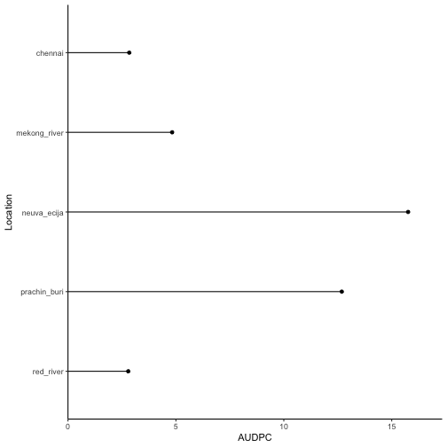

```r
library("dplyr")
library("lubridate")
library("epifitter")
library("ggplot2")

map(
  .x = locations_wth,
  .f = ~ predict_bacterial_blight(emergence = .x$YYYYMMDD[1],
                                  wth = .x)
) %>%
  bind_rows(.id = "location") %>%
  group_by(location) %>%
  summarise(AUDPC(
    time = simday,
    y = intensity,
    y_proportion = FALSE,
    type = "absolute"
  )) %>%
  rename(AUDPC = 2) %>%
  ggplot(aes(
    x = AUDPC,
    xend = 0,
    y = as.factor(location),
    yend = as.factor(location)
  )) +
  geom_segment() +
  geom_point() +
  scale_x_continuous(expand = expansion(mult = c(0, 0.1))) +
  scale_y_discrete(limits = rev) +
  ylab("Location") +
  theme_classic()
```

## Comparing sequential versus parallel methods

It is possible to measure the effect of running the simulations in parallel as compared to sequentially using the *microbenchmark* package. Here an example of how to use benchmarking is shown using the second set of examples showing how to simulate multiple establishment dates with the already created objects from those examples.

Greater gains in efficiency will be realised with more dates, locations, etc. when running in parallel than sequentially.

```r
library("microbenchmark")

plan(multisession, workers = 4)

mbm <- microbenchmark(
  sequential = map2(
    .x = wth,
    .y = emergence_dates,
    .f = ~ predict_bacterial_blight(emergence = .y,
                                    wth = .x)
  ) %>%
    bind_rows(.id = "emergence"),
  parallel = future_map2(
    .x = wth,
    .y = emergence_dates,
    .f = ~ predict_bacterial_blight(emergence = .y,
                              wth = .x),
    .options = furrr_options(seed = NULL)
  ) %>%
    bind_rows(.id = "emergence"),
  unit = "relative"
)

mbm
```

```
#> Unit: relative
#>        expr      min       lq     mean   median       uq       max neval
#>  sequential 1.624557 1.558012 1.503509 1.522304 1.505909 0.7801429   100
#>    parallel 1.000000 1.000000 1.000000 1.000000 1.000000 1.0000000   100
```

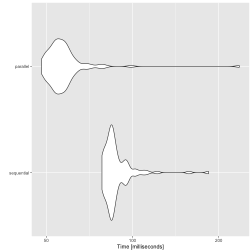

```r
autoplot(mbm)
```